# **Variable relationships with scatter plots using Seaborn**

**Created by: *Leon Gutierrez***

Source code uploaded to [GitHub.com](https://github.com/LeonGutierrez/MADS-SIADS521-Assignment2) alongside a static HTML version for easy readability.

## Contents

- What is Python Seaborn library?
- Installing Seaborn package and getting started
- Objective of this Tutorial
- Seaborn - Strengths and Weaknesses
- Data Set used in this Tutorial
- Why using scatterplots?
- Demostration

## What is Python Seaborn library?

Seaborn is a tabular/declarative plotting library. Plotting libraries like Seaborn, can treat columns of data frames as properties of a graph at a high level. Seaborn is a python library that is used to create graphics in Python. It is built on top of matplotlib and integrated with pandas, scypy, and numpy. This package is used to simplify complex data visualizations. Some of the features Seaborn offers are:

- An API that is dataset-oriented to allow comparison between multiple variables
- Supports multi-plot grids allowing the user to build complex visualizations
- Univariate and bivariate charts to compare between subsets of data
- Availability of different color palettes to better highlight variable patterns
- Estimates and plots linear regression automatically for different types of dependent vaiables
- Availability of different color palettes to better highlight variable patterns

Seaborn aims to make visualization a central part of exploring and understanding data. Its dataset-oriented plotting functions operate on dataframes and arrays containing whole datasets and internally perform the necessary semantic mapping and statistical aggregation to produce informative plots.

**In summary, I chose Seaborn for this tutorial because Seaborn is very simple to use compare to other packages like Matplotlib. I makes hard visualizations easy to to be defined. I personally like that it automatically displays linear regressions when I analyze scatterplots**

## Installing and getting started

There are several options for you to install Seaborn and use it in Python. Any of the following instructions can be run from the python or Jupyter terminals:

Option 1: Use Pip: `pip install seaborn`  
Option 1: Use Pip: `conda install seaborn`  
Option 1: Use Pip from GitHub: `pip install git+https://github.com/mwaskom/seaborn.git`

**It is important to mention that this is an open source package**, so you can install at no cost. However, make sure you keep this version updated to the most recent changes. Just to make sure your dependencies are aligned, I recommend to use conda to install the package.

Dependencies: Python 3.6+

## Objective

The objective of this tutorial is to *demostrate the simplicity and power of Seaborn by **analyzing some visual bivariate relationships***</b>. I especifically explore `lmplot` and `jointplot`. I also present some variations to improve readability and analysis quality.

## Seaborn - Strengths and Weaknesses

**Strengths:**

- Good for style themes right off the box
- Allows for custom color palettes. A list can be created using color codes from https://bulbapedia.bulbagarden.net/wiki/Category:Type_color_templates. Once created, the `palette='newpalette'` can be used

**Weaknesses:**

- Dificult to manipulate dataframes. Easier to pre-format the dataset before it is used in Seaborn
- Library is relatively low-level
- Defaults are not optimal in my opinion (no gridlines, white background, etc.)

## Why using scatterplots to analyze bivariate relationships?

In general, I think scatterplot are a great way to explore your data when you want to find relationships in your data. That relationship can be calculated as a scalar (Pearson or Spearman). However, a visual exploration provides insights not capture by a single number. This exploratory analysis is very useful in cases where you want to predict a value, so one variable's final estimation will depend on the value of another one. In summary, this types of analysis are good in cases:

1. When you want to analize paired numerical data.
2. When trying to determine whether the variables you are analyzing are correlated. This correlation helps determine whether one variable could be used to explain the behavior of the other
3. In classification and regression problems, scatterplots allow you to see these correlations in a way that it is easy to determine explanatory power

## Data Set used in this Tutorial

This dataset is related to red wine variants of the Portuguese "Vinho Verde" wine. This dataset has been used in multiple websites to serve as an example for regression models. For this reason, I think it was a good database for this tutorial. This data is open source and can be downloaded from multiple places. For more details, consult the reference [Cortez et al., 2009]. Due to privacy and logistic issues, only physicochemical (inputs) and sensory (the output) variables are available (e.g. there is no data about grape types, wine brand, wine selling price, etc.).

This dataset is also available from the UCI machine learning repository,

> https://archive.ics.uci.edu/ml/datasets/wine+quality

Quality, is a score between 0 and 10 based on sensory responses. All other variables are based on physicochemical tests.

I decided to use this database not only because it has been widely used to demostrate regression models but because access is easy from multiple locations. Additionally, the data contains sufficient information (1,599 observations)to use it in this context.

Relevant publication: P. Cortez, A. Cerdeira, F. Almeida, T. Matos and J. Reis. Modeling wine preferences by data mining from physicochemical properties. In Decision Support Systems, Elsevier, 47(4):547-553, 2009.

### Demostration

The following cells demostrate the use of Seaborn to create and analyze scatter plots.

```python
###################################################
######1. We first load the dataset reds ###########
###################################################
import pandas as pd
reds = pd.read_csv('https://s3.amazonaws.com/assets.datacamp.com/production/course_1606/datasets/winequality-red.csv',header=0,sep=';')

#### I am adding 2 variables to create categorical classification in the data
reds['Wine Quality'] = np.where(reds['quality']>=6, 'Premium Quality', 'Average Quality')
reds['Acidity'] = np.where(reds['pH']>=3.5, 'Low', 'High')

#### I randomly selected some variables to make the demostration easier (grid)
grid=['residual sugar', 'free sulfur dioxide', 'total sulfur dioxide','pH', 'alcohol', 'Wine Quality', 'Acidity']
reds=reds[grid]

#### Some basic information about the dataset to be used
print('Total number of columns ',reds.shape[1])
print('Total number of rows ',reds.shape[0])
reds.head(5)
```

```
Total number of columns  7
Total number of rows  1599
```

|  | residual sugar | free sulfur dioxide | total sulfur dioxide | pH | alcohol | Wine Quality | Acidity |
| --- | --- | --- | --- | --- | --- | --- | --- |
| 0 | 1.9 | 11.0 | 34.0 | 3.51 | 9.4 | Average Quality | Low |
| 1 | 2.6 | 25.0 | 67.0 | 3.20 | 9.8 | Average Quality | High |
| 2 | 2.3 | 15.0 | 54.0 | 3.26 | 9.8 | Average Quality | High |
| 3 | 1.9 | 17.0 | 60.0 | 3.16 | 9.8 | Premium Quality | High |
| 4 | 1.9 | 11.0 | 34.0 | 3.51 | 9.4 | Average Quality | Low |

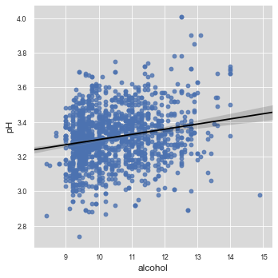

```python
###################################################
#### I randomly selected some variables to  #######
#### make the demostration easier.          #######
###################################################
sns.set_style("darkgrid", {"axes.facecolor": ".85"})    # adding some aethstetics to the plot
sns.lmplot(x="alcohol",                                 # declare the variable on the x axis
            y="pH",                                     # declare the variable on the y axis
            data=reds,                                  # dataframre to be used
            line_kws={'color': 'black'});               # control the color of the regression line
```

**From the above scatterplot**: Although it is possible to see that there is some positive relationship of this two variables, we probably want to explore if other variables might add more insight to this two variables relationship. This tutorial does not explore all Seaborn aesthetic options, however you can run `sns.axes_style()` in order to see all defaul options. Then you can make changes accordingly.

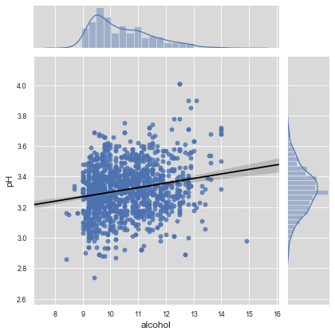

```python
###################################################
#### This variation provides a little       #######
#### twist to the a simple scatter plot     #######
#### It is very simple to define and you    #######
#### are able to display a regression       #######
#### line and see variable distributions    #######
###################################################
sns.jointplot(x="alcohol",
              y="pH",
              data=reds,
              kind="reg",
              line_kws={'color': 'black'})
```

**From the above plot**: This variation from the first 'vanilla' scatterplot adds a view that allows is to see the distribution of each variable individually. Sometimes it might be useful to see such distributions as a way to spot potential anomalies in the data or potential ranges to analize.

[figure not shown]

```python
###################################################
#### With this variation we want to have a  #######
#### better grasp of the same 2 variables   #######
#### but with a secondary variable as the   #######
#### colour encoding variable.              #######
###################################################
pal = sns.dark_palette("palegreen", as_cmap=True)

sns.set_context("paper", rc={"font.size":12,"axes.titlesize":12,"axes.labelsize":12})
sns.lmplot(x="alcohol",
            y="pH",
            hue="Wine Quality",                                   # This option controls the encoding for
            data=reds,
            markers=[".","+"]).set(title = 'Bivariate Analysis',  # Adding additional control over the chart
                            xlabel = 'Free SO2 Content',
                            ylabel = 'Alcohol Content' );
```

**From the above scatterplot:** By adding a hue variable, it is possible to predict or have a sense of variable separation potential. In this case we are trying to determine whether these two variables have the separation potential for the variable `Wine Quality`.

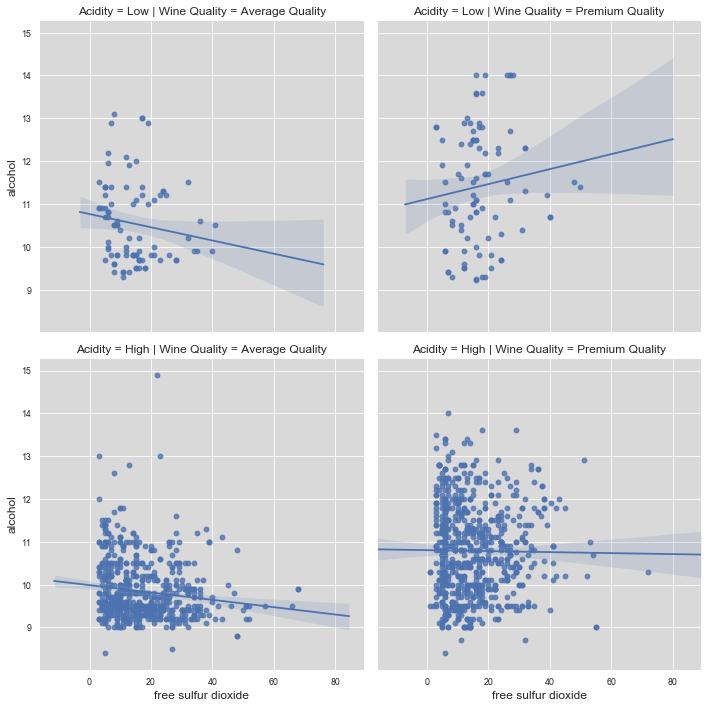

```python
###################################################
#### With this variation we are able to     #######
#### create a grid with Wine Quality and    #######
#### Acidity to determine. The advantage    #######
#### of this approach is that effects are   #######
#### separated for better visualization     #######
###################################################
sns.set_style("darkgrid", {"axes.facecolor": ".85"})
sns.lmplot(x="free sulfur dioxide",
           y="alcohol",
           col="Wine Quality",               # 'col=' and 'row=' Variables that define subsets of the data,
           row="Acidity",                    # which will be drawn on separate facets in the grid
           data=reds)
```

**From the above plots grid:** This option allows to plot data and regression model fits across a FacetGrid. This new perspective is able to separate interacions that are easily spotted with the regression line.

# BEST PRACTICES

Adherence of this tutorial to some of the rules described in:

Ten simple rules for writing and sharing computational analyses in Jupyter Notebooks Adam Rule,Amanda Birmingham,Cristal Zuniga,Ilkay Altintas,Shih-Cheng Huang,Rob Knight,Niema Moshiri,Mai H. Nguyen,Sara Brin Rosenthal,Fernando Pérez,Peter W. Rose Published: July 25, 2019https://doi.org/10.1371/journal.pcbi.1007007

### **Rule 1** Tell a story for an audience:

This tutorial was built in a way that the computational narrative is cohesive with the comments and explanations. Notes, explanations and interpretations were added in order for the user to better understand the package and the practice example

### **Rule 2** Document the process, not just the results:

This tutorial is splitt into different sections. All initial sections primarely document the reasons and background for the process used. So I initially explain details about the library used, the reasons for that, what can the user expect in terms of advantages and disadvantages, etc. Then I proceed to the actual examples. For each example annotations were included in the code and then a brief explanation of what I see from the results

### **Rule 3** Share and explain your data:

In order to follow an structured story flow that is not broken or with pieces that are hard to connect, a table of contents was created. Different types of annotation tags/markdowns were added to improve readability. Additionally, some features like colors were added to improve user engagement.Cell were kept short and susinct so that the user does not loose track of the flow.

### **Rule 8** Share and explain your data:

This code has been uploaded to GitHub.com. This notebook was clearly annotated so that any persont that downloads will be able to replicate results and use this code. Even thoug the data is not updaled to this repository, I provide two locations where this data can be downloaded and the references of the data origins.